# QWE

Примерные вопросы.

https://htmlpreview.github.io/?https://github.com/IvanSibirevV2/HowTo_CPP/blob/main/Тверь_2017/001_НизкийСтарт.html#/source

https://htmlpreview.github.io/?https://github.com/IvanSibirevV2/Kip_papers/blob/main/QWE.html#/source

Перечислить и охарактеризовать подходы к определению операционной системы и ее функций.

https://studfile.net/preview/9394821/page:3/

Дать определение понятию «процесс». Привести классификации процессов.

https://studfile.net/preview/712980/page:5/

Выполнить планирование процессов с использованием алгоритма планирования FCFS. Вычислить среднее время ожидания и среднее время выполнения процессов. Процессы поступают в соответствии с их номерами в таблице:

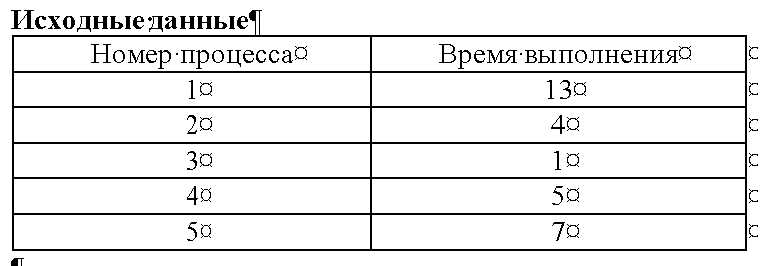

https://www.guru99.com/ru/fcfs-scheduling.html

https://intuit.ru/studies/courses/2192/31/lecture/972?page=3

Перечислить и охарактеризовать функции операционных систем

https://studfile.net/preview/434249/

Перечислить и охарактеризовать состояния процесса. Привести диаграмму переходов состояний процесса

https://studfile.net/preview/16562946/page:6/

Выведите всё строки ниже 14 в файле /etc/group:

Можно на питоне

Дать определение операционной системы. Описать место операционной системы в структуре информационной системы

https://studfile.net/preview/5946827/page:11/м

Вы пишете команду, нажимаете tab - но вместо опций вы видите список файлов. Нормальное ли это поведение. Если нет, в чём заключается проблема и как её решить

CMD POWER SHEL BASH ...

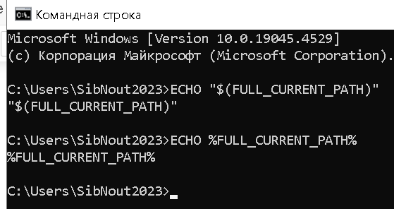

https://habr.com/ru/articles/147870/

Создайте два алиаса с одинаковыми названиями в ~/.bashrc. Какой из них работает.

https://habr.com/ru/companies/otus/articles/745882/

http://meliorem.ru/tools/linux/sozdanie-aliasov-v-obolochke-bash/

И да образ линуха поставить придется

Привести типовую структуру операционной системы. Охарактеризовать взаимодействие основных компонентов

https://studfile.net/preview/5946827/page:11/

Охарактеризовать понятие «планирование процессов». Перечислить и охарактеризовать алгоритмы планирования процессов в операционных системах

https://studfile.net/preview/10012472/page:4/

https://intuit.ru/studies/courses/941/31/lecture/972

Создайте команду getlog, которая будет показывать последние 5 строк файла /var/log/kdump.log и одновременно добавлять вывод в файл mykernellog.

можно на питоне

Перечислить группы пользователей операционной системы. Описать их функции

https://studfile.net/preview/424018/

http://citforum.ru/operating_systems/winntadm/winntadm_05.shtml

Дать определение понятиям «прерывание», «система прерываний». Перечислить и охарактеризовать классы прерываний

https://studfile.net/preview/2566995/

Создайте «команду» (алиас), которая бы сохраняла список алиасов в файле.

Охарактеризовать периоды развития операционных систем

https://studfile.net/preview/1910837/

Вы запускаете команду ls file, но ничего не происходит. У вас подозрения, что кто-то подменил команду ls. Как это проверить?

Выполнить планирование процессов с использованием алгоритма планирования FCFS. Вычислить среднее время ожидания и среднее время выполнения процессов с учетом момента поступления процессов в систему.

https://studfile.net/preview/8927153/

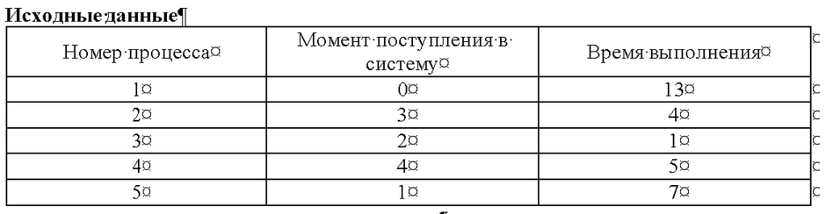

Привести классификацию операционных систем

https://studfile.net/preview/7106230/page:14/

Дать определение понятиям «управление памятью», «менеджер памяти». Перечислить функции операционной системы по управлению памятью

https://studfile.net/preview/4252/page:6/

https://moodle.kstu.ru/mod/page/view.php?id=57

Запишите в файл mykernel последние 10 строк файла /var/log/kdump.log

Перечислить и охарактеризовать виды ядра операционной системы

https://studfile.net/preview/7273204/page:2/

Перечислить и охарактеризовать методы распределения памяти

https://studfile.net/preview/3674957/page:15/

Посмотрите файлы mykernel и /etc/DDD, при этом стандартный вывод направьте в файл result.log, а ошибки в файл /tmp/ERRORS

Рассказать историю развития операционных систем семейства Windows

https://studfile.net/preview/3320360/page:20/

Дать определение оперативной памяти и КЭШ-памяти. Перечислить и охарактеризовать типы адресов и виды адресного пространства вычислительной системы

...

https://studfile.net/preview/7305124/page:2/

...

Вообще это из архитектуры аппаратных средств

Направьте строки с 13 до 20 из файла /etc/group в файл ~/lines, а потом добавьте в этот файл 16 строку из файла /etc/passwd.

Рассказать историю развития операционных систем семейства Unix

https://habr.com/ru/articles/147774/

Дать определение понятию «виртуальная память». Перечислить и охарактеризовать механизмы реализации виртуальной памяти

https://studfile.net/preview/4402813/

Выполнить планирование процессов с использованием невытесняющего алгоритма планирования SJF. Вычислить среднее время ожидания и среднее время выполнения процессов с учетом момента поступления процессов в систему.

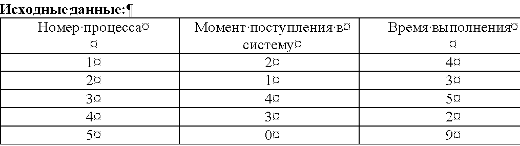

Перечислить и охарактеризовать виды многозадачности, реализуемые в операционных системах

https://studfile.net/preview/3638399/page:10/

Дать определение понятию «виртуальная память». Описать технологию настройки файла подкачки в операционной системе Windows

https://studfile.net/preview/4339466/page:25/

Зайдите в директорию /usr/share/applications . Затем зайдите в директорию /var/log/chrony. Перечислите и попробуйте все способы перемещаться между этими двумя директориями.

Перечислить и охарактеризовать виды интерфейсов пользователя

https://intuit.ru/studies/courses/3609/851/lecture/31652?page=3

Дать определение оперативной памяти и виртуальной памяти. Описать технологию преобразования виртуальных адресов в физические адреса

https://studfile.net/preview/9512666/page:6/

Создайте директорию myfiles в домашней директории вашего пользователя. Скопируйте файл /etc/passwd в эту директорию. Откройте файл с помощью nano, найдите и удалите 16 строчку.

Дать определение понятию «файл». Пояснить понятие «имя файла». Перечислить и охарактеризовать атрибуты файлов

https://studfile.net/preview/6058556/page:7/

Перечислить и охарактеризовать политики паролей пользователей в операционной системе Windows

https://studfile.net/preview/9395592/page:3/

Выполнить планирование процессов с использованием алгоритма планирования RR. Вычислить среднее время ожидания и среднее время выполнения процессов. Величина кванта времени = 5.

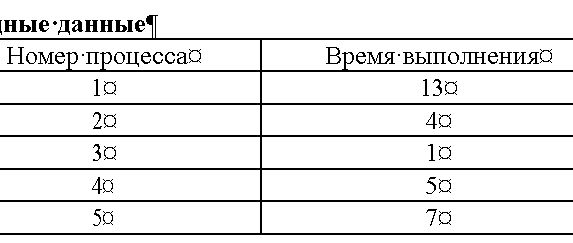

Пояснить понятие «файловая структура». Перечислить и охарактеризовать состояния и типы каталогов

https://studfile.net/preview/9573953/page:4/

Вы открыли файл ~/.bashrc, добавили в нём алиас, сохранили и закрыли текстовой редактор. Но алиас не работает. В чём может быть причина.

Создайте команду getlog, которая будет показывать последние 5 строк файла /var/log/kdump.log и одновременно добавлять вывод в файл mykernellog.

Дать определение понятию «файловая система». Перечислить основные функции файловых систем. Привести примеры существующих файловых систем

https://studfile.net/preview/5795257/page:18/

Охарактеризовать состав и возможности реестра операционной системы Windows

https://studfile.net/preview/7620357/page:15/

Перечислить и охарактеризовать основные блоки утилиты BIOS SETUP

https://studfile.net/preview/5514356/page:7/

https://www.ixbt.com/mainboard/setup.html

Перечислить и охарактеризовать функциональные особенности операционной системы семейства Unix

https://studfile.net/preview/963653/page:9/

Выполнить планирование процессов с использованием невытесняющего алгоритма планирования SJF. Вычислить среднее время ожидания и среднее время выполнения процессов.

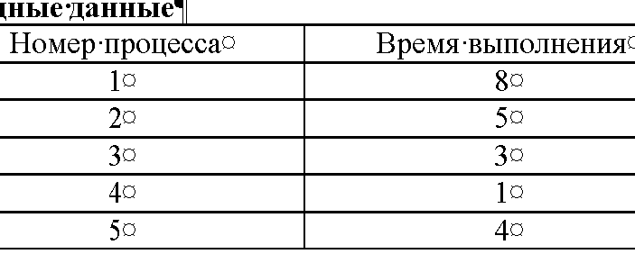

Перечислить и охарактеризовать команды операционной системы MS DOS для работы с дисками

https://studfile.net/preview/4001835/page:20/

https://inf-3.narod.ru/pm1/lab_dos.pdf

Охарактеризовать функциональные особенности операционной системы Linux

https://studfile.net/preview/4444703/

https://blog.skillfactory.ru/glossary/linux/

Выполнить планирование процессов с использованием невытесняющего алгоритма планирования SJF. Вычислить среднее время ожидания и среднее время выполнения процессов с учетом момента поступления процессов в систему.

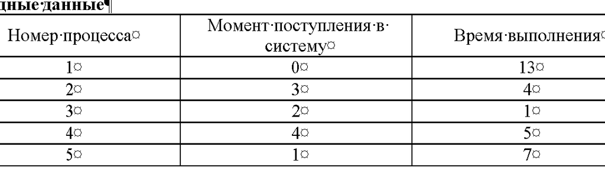

Перечислить и охарактеризовать команды операционной системы MS DOS для работы с файлами

https://phys.bspu.by/static/lib/inf/posob/stu_m/glaves/glava9/gl_9_3.htm

Дать определение сетевой операционной системы. Перечислить особенности сетевых операционных систем

https://studfile.net/preview/3646/

https://www.geeksforgeeks.org/what-is-a-network-operating-system/

Перечислить и охарактеризовать команды операционной системы Linus для работы с дисками

https://otus.ru/nest/post/830/

https://habr.com/ru/companies/otus/articles/713112/

Дать определение распределенной операционной системы. Перечислить особенности распределенных операционных систем

https://studfile.net/preview/6211039/page:5/

https://www.geeksforgeeks.org/what-is-a-distributed-operating-system/

Описать структурную схему/архитектуру современной операционной системы Windows

https://studfile.net/preview/9768333/page:9/

https://fb.ru/article/455504/arhitektura-windows-opisanie-vidyi-struktura

Задачи ОС по управлению операциями ввода-вывода. Многослойная модель подсистемы ввода-вывода.

https://studfile.net/preview/5687200/page:5/

https://en.ppt-online.org/25582

Перечислить и охарактеризовать функции ядра операционной системы Windows

https://studfile.net/preview/9865015/

https://habr.com/ru/articles/428469/

Перечислить и охарактеризовать операционные системы, предназначенные для мобильных устройств

https://www.ixbt.com/live/mobile/istoriya-mobilnyh-operacionnyh-sistem-vspomnim-kakimi-oni-byli.html

https://www.oknemuan.ru/files/os/Lektsiya_4_Operatsionnye_sistemy_1698496446.pdf

Опишите механизмы управления доступом к ресурсам, параметры политики безопасности, относящиеся к аутентификации и авторизации пользователей при интерактивном входе. Создайте новую группу пользователей с именем «Моя группа». Создайте папку free_access, в которую преподаватели могут записывать и читать файлы, а члены группы Моя группа – только читать.

Архитектура, назначение и области применения Операционной системы специального назначения Astra Linux Special Edition

https://rusbitech.ru/assets/press/AstraLinux.pdf

https://yztm.ru/wp-content/uploads/2017/09/Opisanie_primeneniya.pdf

Основные подходы к построению защищенных операционных систем. Стандарты безопасности операционных систем.

https://studfile.net/preview/1872555/page:20/

https://www.geeksforgeeks.org/system-protection-in-operating-system/

Выполнить планирование процессов с использованием алгоритма RR. Вычислить среднее время ожидания и среднее время выполнения процессов. Величина кванта времени = 1.

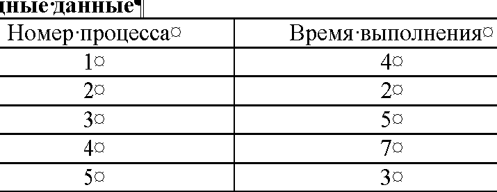

Классификация угроз ОС. Источники угроз информационной безопасности и объекты воздействия.

https://searchinform.ru/informatsionnaya-bezopasnost/osnovy-ib/ugrozy-informatsionnoj-bezopasnosti/

https://ru.wikipedia.org/wiki/Угрозы_информационной_безопасности

https://learn.urfu.ru/resource/index/data/resource_id/40977/revision_id/0

Охарактеризовать механизмы защиты операционной системы семейства Unix

https://studfile.net/preview/1049721/page:8/

https://habr.com/ru/companies/ruvds/articles/523872/

Выполнить планирование процессов с использованием алгоритма RR. Вычислить среднее время ожидания и среднее время выполнения процессов. Величина кванта времени = 3.

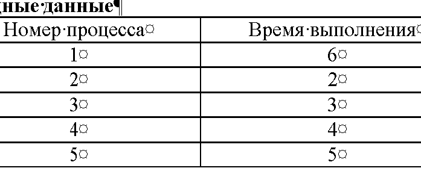

Требования, применяемые к виртуализации. Гипервизоры. Технологии эффективной виртуализации. Виртуализация памяти. Виртуализация ввода-вывода. Виртуальные устройства.

https://smartiqa.ru/blog/virtualization

https://habr.com/ru/articles/657677/

https://firstvds.ru/technology/virtualizaciya-virtualnye-mashiny-i-ih-raznovidnosti

Охарактеризовать механизмы защиты операционной системы семейства Windows

https://studfile.net/preview/1673752/page:11/

https://studopedia.ru/3_12432_osnovnie-zashchitnie-mehanizmi-os-semeystva-WINDOWS.html

Выполнить планирование процессов с использованием алгоритма RR. Вычислить среднее время ожидания и среднее время выполнения процессов. Величина кванта времени = 4.

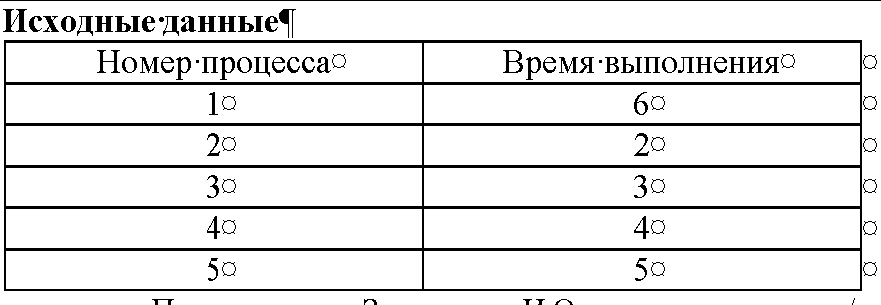

Описать структурную схему/архитектуру операционной системы Linux

https://habr.com/ru/articles/531872/

https://studfile.net/preview/4402807/

Перечислите требования, предъявляемые к современным операционным системам

https://studfile.net/preview/4034502/page:13/

https://ppt-online.org/526707

Проанализируйте механизмы управления учетными записями пользователей в ОС Windows. Создайте новую группу пользователей с именем «Начинающие пользователи». В чем целесообразность разбиения множества пользователей на группы? Какие группы пользователей создаются автоматически? Создайте новую учетную запись с произвольным логическим именем. Опишите порядок назначения прав пользователям.

Классификация угроз ОС. Источники угроз информационной безопасности и объекты воздействия.

Проанализируйте механизмы управления учетными записями пользователей в ОС Windows. Создайте новую группу пользователей с именем «Начинающие пользователи». В чем целесообразность разбиения множества пользователей на группы? Какие группы пользователей создаются автоматически? Создайте новую учетную запись с произвольным логическим именем. Опишите порядок назначения прав пользователям.

Классификация угроз ОС. Источники угроз информационной безопасности и объекты воздействия.

https://iee.unn.ru/wp-content/uploads/sites/9/2018/02/2.Inf.ugrozy-vred.programmykomp.prestupleniya.pdf

https://studfile.net/preview/4518611/page:3/

Одной командой создайте файлы file20-29. Одной командой создайте жёсткие ссылки на эти файлы в скрытой директории. Одной командой удалите эти файлы в текущей директории.

Что происходит с данными при перемещении в рамках одной файловой системы и разных файловых систем.

https://studfile.net/preview/8754543/page:3/

Используя поиск в less, найдите слово games в файле /etc/passwd.

Создайте символическую ссылку на существующие файл и директорию, а также на несуществующие файл и директорию.

Описать структурную схему/архитектуру операционной системы Linux

https://studfile.net/preview/5457977/

Перечислите требования, предъявляемые к современным операционным системам

https://studfile.net/preview/4034502/page:13/

https://ppt-online.org/526707

Создайте файл file1 в директории dir1. Переименуйте файл в file2, не заходя в директорию с помощью cd.